# Nick Moores CLAV Data Analysis

Nick Moores

June 5, 2015

### Intro and Imports

I first clear all previous variables and load libraries for data manipulation and graphing

```r
rm(list=ls())

library(psych)
library(tidyr)
library(dplyr)
library(ggplot2)
library(stringdist)
library(irr)
library(gpairs)
library(mcmc)
library(boot)
library(mlogit)
library(corrplot)
library(GPArotation)
library(RColorBrewer)
library(GGally)
library(lme4)
library(lmerTest)
library(grid)
library(reshape2)
```

And define some useful functions for computing measurement error

```r
sem <- function(x) {sd(x)/sqrt(length(x))}
ci95 <- function(x) {3.96*sem(x)}
```

And I load in the data from the data files:

```r
d <- data.frame() #initializes df var
files <- dir("~/Documents/Research/CLAV_iPad/ResultsCSVs/",pattern="*.csv")

for (f in files) { #iterates through folder
  df <- read.csv(paste("~/Documents/Research/CLAV_iPad/ResultsCSVs/",
                       f,sep=""))
  d <- rbind(d, df) #constructs master dataframe
}
glimpse(d)
```

```
## Observations: 1431
## Variables:
## $ subjectID       (int) 1, 1, 1, 1, 1, 1, 1, 1, 1, 1, 1, 1, 1, 1, 1, 1...
## $ list_number     (int) 1, 1, 1, 1, 1, 1, 1, 1, 1, 1, 1, 1, 1, 1, 1, 1...
## $ tar_name        (fctr) Watch, Clock, Boot, Scissors, Pajamas, Swimsu...
## $ voice_type      (fctr) mens, mens, mens, mens, mens, mens, mens, men...
## $ comp_type       (fctr) womens, womens, womens, womens, womens, women...
## $ has_comp        (fctr) no_competitor, no_competitor, competitor, com...
## $ upper_left      (fctr) Distractors/banana.jpg, Distractors/bee.jpg, ...
## $ upper_right     (fctr) Distractors/cow.jpg, Distractors/celery.jpg, ...
## $ lower_left      (fctr) Distractors/violin.jpg, clock_mens.jpg, boot_...
## $ lower_right     (fctr) watch_mens.jpg, Distractors/drum.jpg, boot_me...
## $ clicked         (fctr) lowerRight, lowerLeft, lowerRight, upperRight...
## $ correct         (fctr) lowerRight, lowerLeft, lowerRight, upperRight...
## $ AudioPlayedTime (dbl) 7.397483, 10.497347, 13.515941, 16.598390, 19....
## $ TapTime         (dbl) 9.235737, 12.254331, 15.336780, 18.500499, 21....
## $ RT              (dbl) 1.838254, 1.756984, 1.820839, 1.902109, 1.4725...
```

### Clean the Dataframe

I get a sense of the distribution of the data

```r
m.rt <- exp(mean(log(d$RT),na.rm=TRUE)) #take log average of RT: average natural logs of RTs, then take the exponential of that
sd.rt <- exp(sd(log(d$RT),na.rm=TRUE)) #geometric standard deviation: exponentiated value of the standard deviation of the log-transformed values
```

```
## stat_bin: binwidth defaulted to range/30. Use 'binwidth = x' to adjust this.
```

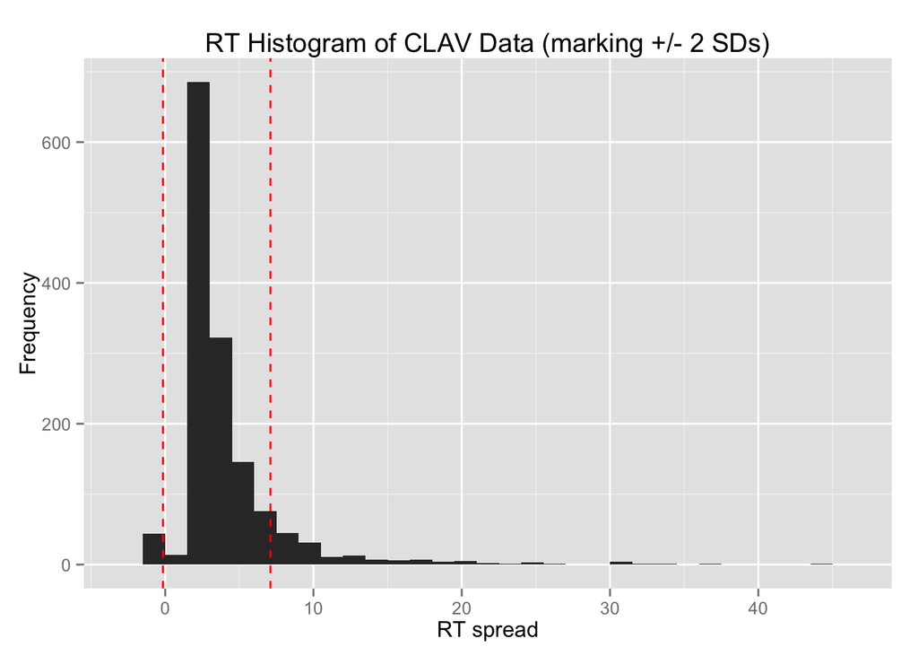

```r
qplot(RT, data=d) +
  geom_vline(xintercept=m.rt + 2*sd.rt, col="red", lty=2) + #lets us view how much is spread 2 SDs above mean
  geom_vline(xintercept=m.rt - 2*sd.rt, col="red", lty=2) + #lets us view how much is spread 2 SDs below mean
  xlab("RT spread") +
  ylab("Frequency") +
  ggtitle("RT Histogram of CLAV Data (marking +/- 2 SDs)")
```

```r
with(d, mean(RT > m.rt - 2*sd.rt & RT < m.rt + 2*sd.rt)) #calculate the mean to check what it is in console
```

```
## [1] 0.8574423
```

```r
df <- subset(d, RT > m.rt - 2*sd.rt & RT < m.rt + 2*sd.rt) #get the subset of the df between 2 SDs of mean (dat's legit, man)
df <- subset(d, RT > 0) #gets rid of negative RTs
##change up some minor aesthetic details##
#df <- subset(df,select=-c(X)) #remove the mysterious X column
df$subjectID <- factor(df$subjectID) #convert subjectID to a factor
df$is.correct <- df$clicked==df$correct #add a correct column as a logical of whether 'clicked' matched 'correct'
```

*Merge in Demographics*

```r
glimpse(df) #quick overview of the df before the merge
```

```
## Observations: 1387
## Variables:
## $ subjectID       (fctr) 1, 1, 1, 1, 1, 1, 1, 1, 1, 1, 1, 1, 1, 1, 1, ...
## $ list_number     (int) 1, 1, 1, 1, 1, 1, 1, 1, 1, 1, 1, 1, 1, 1, 1, 1...
## $ tar_name        (fctr) Watch, Clock, Boot, Scissors, Pajamas, Swimsu...
## $ voice_type      (fctr) mens, mens, mens, mens, mens, mens, mens, men...
## $ comp_type       (fctr) womens, womens, womens, womens, womens, women...
## $ has_comp        (fctr) no_competitor, no_competitor, competitor, com...
## $ upper_left      (fctr) Distractors/banana.jpg, Distractors/bee.jpg, ...
## $ upper_right     (fctr) Distractors/cow.jpg, Distractors/celery.jpg, ...
## $ lower_left      (fctr) Distractors/violin.jpg, clock_mens.jpg, boot_...
## $ lower_right     (fctr) watch_mens.jpg, Distractors/drum.jpg, boot_me...
## $ clicked         (fctr) lowerRight, lowerLeft, lowerRight, upperRight...
## $ correct         (fctr) lowerRight, lowerLeft, lowerRight, upperRight...
## $ AudioPlayedTime (dbl) 7.397483, 10.497347, 13.515941, 16.598390, 19....
## $ TapTime         (dbl) 9.235737, 12.254331, 15.336780, 18.500499, 21....
## $ RT              (dbl) 1.838254, 1.756984, 1.820839, 1.902109, 1.4725...
## $ is.correct      (lgl) TRUE, TRUE, TRUE, TRUE, TRUE, TRUE, TRUE, TRUE...
```

```r
demos <- read.csv("~/Documents/Research/CLAV_iPad/clav_demographics.csv")
glimpse(demos) #get a quick look at the demos file to see if something's amiss
```

```
## Observations: 60
## Variables:
## $ subjectID (int) 1, 3, 4, 6, 7, 8, 9, 10, 11, 12, 15, 16, 17, 18, 19,...
## $ name      (fctr) Claire Laploir, Zoe Figueroa, Shen Harman, Daniel S...
## $ gender    (fctr) Female, Female, Male, Male, Male, Male, Male, Femal...
## $ BirthDate (fctr) 11/25/09, 8/27/10, 2/15/10, 6/26/10, 12/4/10, 8/28/...
## $ TestDate  (fctr) 7/8/14, 7/9/14, 7/9/14, 7/9/14, 7/15/14, 7/15/14, 7...
## $ age       (int) 4, 3, 4, 4, 3, 4, 4, 4, 4, 3, 4, 4, 3, 5, 3, 3, 3, 3...
```

```r
df <- merge(df, demos, by.x="subjectID", by.y="subjectID") #by.x says in the df, merge by subjectID and by.y says in the demos df merge by subjectID
df$age <- factor(df$age)
correct_df <- df %>% filter(is.correct==TRUE)
glimpse(df) #check this to make sure it merged correctly!
```

```
## Observations: 1387
## Variables:
## $ subjectID       (fctr) 1, 1, 1, 1, 1, 1, 1, 1, 1, 1, 1, 1, 1, 1, 1, ...
## $ list_number     (int) 1, 1, 1, 1, 1, 1, 1, 1, 1, 1, 1, 1, 1, 1, 1, 1...
## $ tar_name        (fctr) Watch, Clock, Boot, Scissors, Pajamas, Swimsu...
## $ voice_type      (fctr) mens, mens, mens, mens, mens, mens, mens, men...
## $ comp_type       (fctr) womens, womens, womens, womens, womens, women...
## $ has_comp        (fctr) no_competitor, no_competitor, competitor, com...
## $ upper_left      (fctr) Distractors/banana.jpg, Distractors/bee.jpg, ...
## $ upper_right     (fctr) Distractors/cow.jpg, Distractors/celery.jpg, ...
## $ lower_left      (fctr) Distractors/violin.jpg, clock_mens.jpg, boot_...
## $ lower_right     (fctr) watch_mens.jpg, Distractors/drum.jpg, boot_me...
## $ clicked         (fctr) lowerRight, lowerLeft, lowerRight, upperRight...
## $ correct         (fctr) lowerRight, lowerLeft, lowerRight, upperRight...
## $ AudioPlayedTime (dbl) 7.397483, 10.497347, 13.515941, 16.598390, 19....
## $ TapTime         (dbl) 9.235737, 12.254331, 15.336780, 18.500499, 21....
## $ RT              (dbl) 1.838254, 1.756984, 1.820839, 1.902109, 1.4725...
## $ is.correct      (lgl) TRUE, TRUE, TRUE, TRUE, TRUE, TRUE, TRUE, TRUE...
## $ name            (fctr) Claire Laploir, Claire Laploir, Claire Laploi...
## $ gender          (fctr) Female, Female, Female, Female, Female, Femal...
## $ BirthDate       (fctr) 11/25/09, 11/25/09, 11/25/09, 11/25/09, 11/25...
## $ TestDate        (fctr) 7/8/14, 7/8/14, 7/8/14, 7/8/14, 7/8/14, 7/8/1...
## $ age             (fctr) 4, 4, 4, 4, 4, 4, 4, 4, 4, 4, 4, 4, 4, 4, 4, ...
```

### Analysis: Aggregating Mean RTs and Proportion Correct

```r
plot.style <- theme(panel.grid.major=element_blank(), legend.position="right", plot.title=element_text(face="bold", size=14), axis.title=element_text(size=12))
PD <- position_dodge(.9)

####Plot Reaction Time by Age
#quartz()
rts <- aggregate(RT ~ has_comp + age, correct_df, mean) #aggregate mean RTs by voice, trial type
rts.sd <- aggregate(RT ~ has_comp + age, correct_df, sd)
rts.SEM <- aggregate(RT ~ has_comp + age, correct_df, sem)
rts$SEM <- rts.SEM[,3]

rts
```

```
##        has_comp age       RT       SEM
## 1    competitor   3 5.217213 0.6102982
## 2 no_competitor   3 4.861902 0.2888979
## 3    competitor   4 4.496479 0.2805265
## 4 no_competitor   4 3.513084 0.1346496
## 5    competitor   5 4.080974 0.3795442
## 6 no_competitor   5 3.730042 0.2179812
```

```r
rts.sd
```

```
##        has_comp age       RT
## 1    competitor   3 6.163709
## 2 no_competitor   3 4.095835
## 3    competitor   4 3.836143
## 4 no_competitor   4 2.228847
## 5    competitor   5 4.344082
## 6 no_competitor   5 3.082719
```

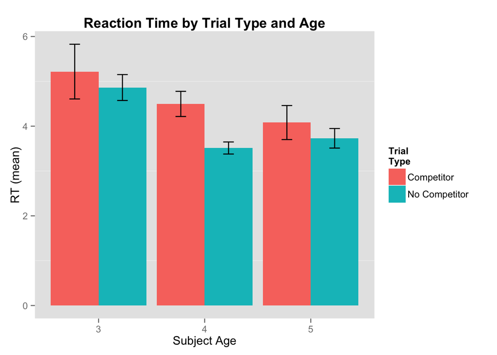

```r
qplot(age, RT, fill=has_comp, #plot bar graph with aggregated means dataframe
      geom="bar",
      position="dodge",
      stat="identity",
      data=rts) +
      geom_errorbar(aes(ymin=RT-SEM, ymax=RT+SEM), colour="black", width=.2, position=PD) +
      xlab("Subject Age") +
      ylab("RT (mean)") +
      ggtitle("Reaction Time by Trial Type and Age") +
      scale_fill_discrete(name="Trial\nType",labels=c("Competitor","No Competitor")) +
      plot.style
```

```r
####Plot Proportion Correct by Age
#quartz()
prop.correct <- aggregate(is.correct ~ has_comp + age, df, mean)
prop.correct.sd <- aggregate(is.correct ~ has_comp + age, df, sd)
prop.correct.SEM <- aggregate(is.correct ~ has_comp + age, df, sem)
prop.correct$SEM <- prop.correct.SEM[,3]

prop.correct
```

```
##        has_comp age is.correct         SEM
## 1    competitor   3  0.4857143 0.034571604
## 2 no_competitor   3  0.9220183 0.018202713
## 3    competitor   4  0.6654804 0.028196772
## 4 no_competitor   4  0.9750890 0.009314059
## 5    competitor   5  0.6717949 0.033712438
## 6 no_competitor   5  0.9900990 0.006983620
```

```r
prop.correct.sd
```

```
##        has_comp age is.correct
## 1    competitor   3 0.50099013
## 2 no_competitor   3 0.26875984
## 3    competitor   4 0.47266403
## 4 no_competitor   4 0.15613207
## 5    competitor   5 0.47076857
## 6 no_competitor   5 0.09925589
```

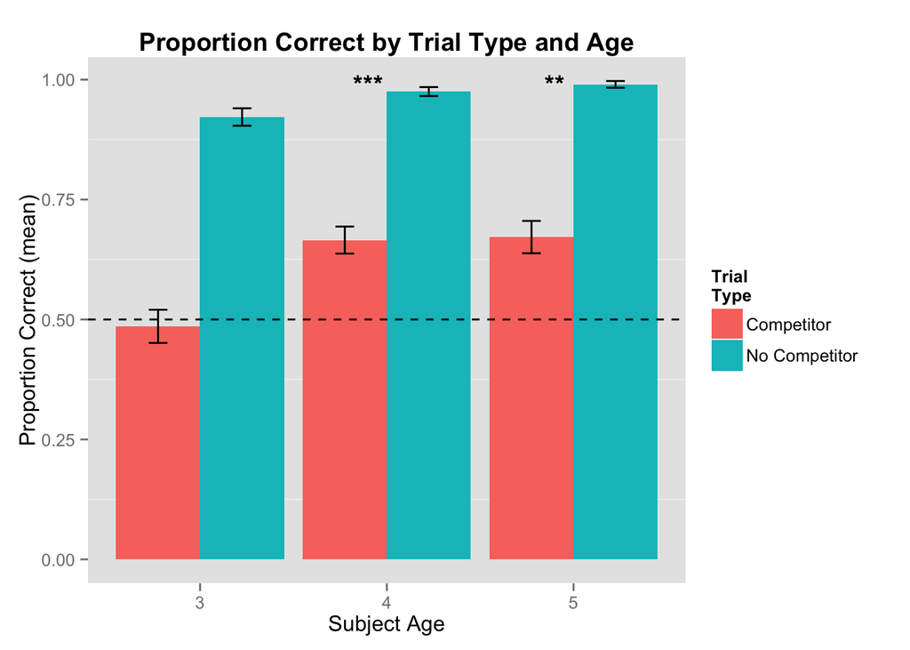

```r
qplot(age, is.correct, fill=has_comp, #plot bar graph with aggregated corrects dataframe
      geom="bar",
      position="dodge",
      stat="identity",
      data=prop.correct) +
  geom_errorbar(aes(ymin=is.correct-SEM, ymax=is.correct+SEM), colour="black", width=.2, position=PD) +
  geom_hline(yintercept=.50,linetype="dashed") +
  xlab("Subject Age") +
  ylab("Proportion Correct (mean)") +
  ggtitle("Proportion Correct by Trial Type and Age") +
  scale_fill_discrete(name="Trial\nType",labels=c("Competitor","No Competitor")) +
  plot.style +
  geom_text(aes(1.9,0.99,label="***"),colour="black",size=5) +
  geom_text(aes(2.9,0.99,label="**"),colour="black",size=5)
```

### Mixed Effects Modeling

```r
###Mixed Effect Correct Model without Interaction
stereotype.mixed.model <- glmer(is.correct ~ age + voice_type + has_comp + (1|subjectID) +
                           (1|tar_name), data=df, family=binomial, na.action=na.omit)
summary(stereotype.mixed.model)
```

```
## Generalized linear mixed model fit by maximum likelihood (Laplace
##   Approximation) [glmerMod]
##  Family: binomial  ( logit )
## Formula: is.correct ~ age + voice_type + has_comp + (1 | subjectID) +
##     (1 | tar_name)
##    Data: df
##
##      AIC      BIC   logLik deviance df.resid
##   1105.0   1141.7   -545.5   1091.0     1380
##
## Scaled residuals:
##     Min      1Q  Median      3Q     Max
## -6.4405  0.1130  0.1811  0.5468  1.6416
##
## Random effects:
##  Groups    Name        Variance Std.Dev.
##  subjectID (Intercept) 0.2385   0.4883
##  tar_name  (Intercept) 0.1613   0.4016
## Number of obs: 1387, groups:  subjectID, 59; tar_name, 23
##
## Fixed effects:
##                       Estimate Std. Error z value Pr(>|z|)
## (Intercept)           -0.05314    0.21321  -0.249 0.803160
## age4                   0.88585    0.23685   3.740 0.000184 ***
## age5                   0.98386    0.26066   3.775 0.000160 ***
## voice_typewomens      -0.15790    0.15520  -1.017 0.308977
## has_compno_competitor  3.01465    0.22532  13.379  < 2e-16 ***
## ---
## Signif. codes:  0 '***' 0.001 '**' 0.01 '*' 0.05 '.' 0.1 ' ' 1
##
## Correlation of Fixed Effects:
##             (Intr) age4   age5   vc_typ
## age4        -0.611
## age5        -0.554  0.499
## voc_typwmns -0.377  0.001 -0.002
## hs_cmpn_cmp -0.208  0.103  0.098 -0.003
```

```r
###Mixed Effect Correct Model with Gender, no interaction
stereotype.mixed.gender.model <- glmer(is.correct ~ age + gender + voice_type + has_comp + (1|subjectID) +
                                  (1|tar_name), data=df, family=binomial, na.action=na.omit)
summary(stereotype.mixed.gender.model)
```

```
## Generalized linear mixed model fit by maximum likelihood (Laplace
##   Approximation) [glmerMod]
##  Family: binomial  ( logit )
## Formula:
## is.correct ~ age + gender + voice_type + has_comp + (1 | subjectID) +
##     (1 | tar_name)
##    Data: df
##
##      AIC      BIC   logLik deviance df.resid
##   1097.7   1139.5   -540.8   1081.7     1379
##
## Scaled residuals:
##     Min      1Q  Median      3Q     Max
## -7.2061  0.1077  0.1810  0.5294  1.6457
##
## Random effects:
##  Groups    Name        Variance Std.Dev.
##  subjectID (Intercept) 0.1563   0.3954
##  tar_name  (Intercept) 0.1605   0.4006
## Number of obs: 1387, groups:  subjectID, 59; tar_name, 23
##
## Fixed effects:
##                       Estimate Std. Error z value Pr(>|z|)
## (Intercept)             0.2095     0.2190   0.956  0.33894
## age4                    0.9156     0.2200   4.162 3.15e-05 ***
## age5                    1.0697     0.2448   4.370 1.24e-05 ***
## genderMale             -0.5922     0.1892  -3.130  0.00175 **
## voice_typewomens       -0.1533     0.1555  -0.986  0.32412
## has_compno_competitor   3.0180     0.2257  13.372  < 2e-16 ***
## ---
## Signif. codes:  0 '***' 0.001 '**' 0.01 '*' 0.05 '.' 0.1 ' ' 1
##
## Correlation of Fixed Effects:
##             (Intr) age4   age5   gndrMl vc_typ
## age4        -0.516
## age5        -0.432  0.499
## genderMale  -0.384 -0.079 -0.149
## voc_typwmns -0.368  0.002 -0.003  0.003
## hs_cmpn_cmp -0.171  0.116  0.115 -0.083 -0.003
```

```r
###Compare the age and age + gender models
anova(stereotype.mixed.model,stereotype.mixed.gender.model)
```

```
## Data: df
## Models:
## stereotype.mixed.model: is.correct ~ age + voice_type + has_comp + (1 | subjectID) +
## stereotype.mixed.model:     (1 | tar_name)
## stereotype.mixed.gender.model: is.correct ~ age + gender + voice_type + has_comp + (1 | subjectID) +
## stereotype.mixed.gender.model:     (1 | tar_name)
##                               Df    AIC    BIC  logLik deviance  Chisq
## stereotype.mixed.model         7 1105.0 1141.7 -545.51   1091.0
## stereotype.mixed.gender.model  8 1097.7 1139.5 -540.83   1081.7 9.3696
##                               Chi Df Pr(>Chisq)
## stereotype.mixed.model
## stereotype.mixed.gender.model      1   0.002206 **
## ---
## Signif. codes:  0 '***' 0.001 '**' 0.01 '*' 0.05 '.' 0.1 ' ' 1
```

```r
###Mixed Effect Correct Model with Gender, with interaction
stereotype.mixed.gender.int.model <- glmer(is.correct ~ age * gender + voice_type + has_comp + (1|subjectID) +
                                         (1|tar_name), data=df, family=binomial, na.action=na.omit)
summary(stereotype.mixed.gender.int.model)
```

```
## Generalized linear mixed model fit by maximum likelihood (Laplace
##   Approximation) [glmerMod]
##  Family: binomial  ( logit )
## Formula:
## is.correct ~ age * gender + voice_type + has_comp + (1 | subjectID) +
##     (1 | tar_name)
##    Data: df
##
##      AIC      BIC   logLik deviance df.resid
##   1101.1   1153.5   -540.6   1081.1     1377
##
## Scaled residuals:
##     Min      1Q  Median      3Q     Max
## -7.6200  0.1077  0.1827  0.5308  1.6283
##
## Random effects:
##  Groups    Name        Variance Std.Dev.
##  subjectID (Intercept) 0.1525   0.3905
##  tar_name  (Intercept) 0.1606   0.4007
## Number of obs: 1387, groups:  subjectID, 59; tar_name, 23
##
## Fixed effects:
##                       Estimate Std. Error z value Pr(>|z|)
## (Intercept)             0.1922     0.2482   0.774 0.438714
## age4                    0.8720     0.3061   2.848 0.004396 **
## age5                    1.2369     0.3740   3.308 0.000941 ***
## genderMale             -0.5534     0.3185  -1.737 0.082315 .
## voice_typewomens       -0.1540     0.1555  -0.991 0.321856
## has_compno_competitor   3.0169     0.2256  13.370  < 2e-16 ***
## age4:genderMale         0.0752     0.4343   0.173 0.862535
## age5:genderMale        -0.2728     0.4930  -0.553 0.580078
## ---
## Signif. codes:  0 '***' 0.001 '**' 0.01 '*' 0.05 '.' 0.1 ' ' 1
##
## Correlation of Fixed Effects:
##             (Intr) age4   age5   gndrMl vc_typ hs_cm_ ag4:gM
## age4        -0.623
## age5        -0.507  0.418
## genderMale  -0.583  0.472  0.385
## voc_typwmns -0.331  0.012 -0.002  0.011
## hs_cmpn_cmp -0.142  0.067  0.069 -0.063 -0.003
## age4:gndrMl  0.432 -0.699 -0.288 -0.732 -0.016  0.023
## age5:gndrMl  0.378 -0.311 -0.753 -0.643 -0.001  0.007  0.474
```

```r
###Compare the age + gender and age * gender models
anova(stereotype.mixed.gender.model,stereotype.mixed.gender.int.model) #interaction terms dont give a significantly better model
```

```
## Data: df
## Models:
## stereotype.mixed.gender.model: is.correct ~ age + gender + voice_type + has_comp + (1 | subjectID) +
## stereotype.mixed.gender.model:     (1 | tar_name)
## stereotype.mixed.gender.int.model: is.correct ~ age * gender + voice_type + has_comp + (1 | subjectID) +
## stereotype.mixed.gender.int.model:     (1 | tar_name)
##                                   Df    AIC    BIC  logLik deviance  Chisq
## stereotype.mixed.gender.model      8 1097.7 1139.5 -540.83   1081.7
## stereotype.mixed.gender.int.model 10 1101.1 1153.5 -540.55   1081.1 0.5498
##                                   Chi Df Pr(>Chisq)
## stereotype.mixed.gender.model
## stereotype.mixed.gender.int.model      2     0.7597
```

### Measure Gender Effects Across Age

```r
correct.gender <- aggregate(is.correct ~ has_comp + gender, df, mean)
correct.gender.sd <- aggregate(is.correct ~ has_comp + gender, df, sd)
correct.gender.SEM <- aggregate(is.correct ~ has_comp + gender, df, sem)
correct.gender$SEM <- correct.gender.SEM[,3]

correct.gender
```

```
##        has_comp gender is.correct         SEM
## 1    competitor Female  0.6646884 0.025755127
## 2 no_competitor Female  0.9735294 0.008718795
## 3    competitor   Male  0.5616046 0.026598595
## 4 no_competitor   Male  0.9529086 0.011164653
```

```r
correct.gender.sd
```

```
##        has_comp gender is.correct
## 1    competitor Female  0.4728013
## 2 no_competitor Female  0.1607666
## 3    competitor   Male  0.4969028
## 4 no_competitor   Male  0.2121284
```

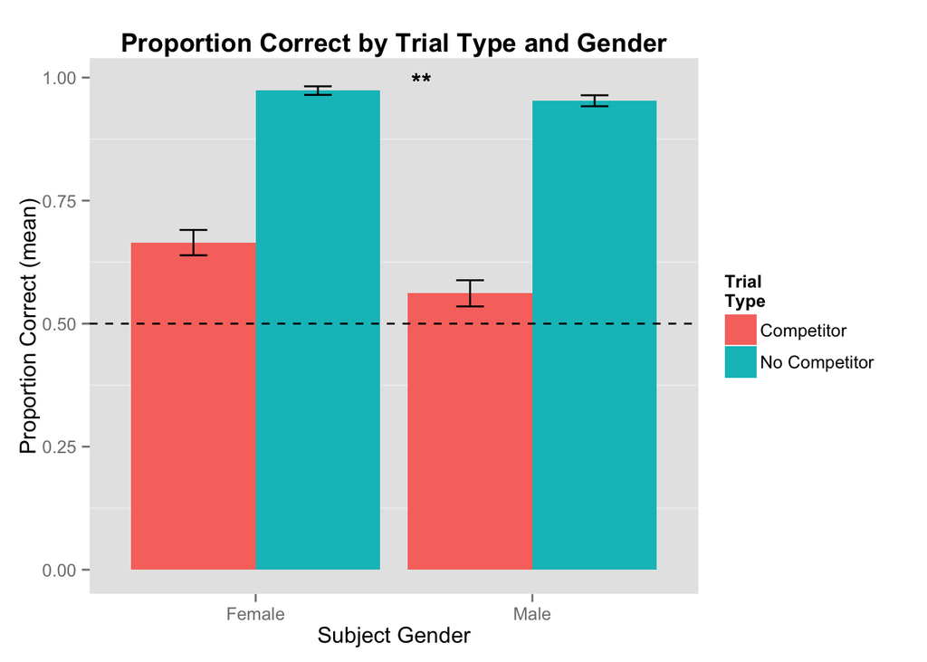

```r
#quartz()
qplot(gender, is.correct, fill=has_comp, #plot bar graph with aggregated corrects dataframe
      geom="bar",
      position="dodge",
      stat="identity",
      data=correct.gender) +
  geom_errorbar(aes(ymin=is.correct-SEM, ymax=is.correct+SEM), colour="black", width=.2, position=PD) +
  geom_hline(yintercept=.50,linetype="dashed") +
  xlab("Subject Gender") +
  ylab("Proportion Correct (mean)") +
  ggtitle("Proportion Correct by Trial Type and Gender") +
  scale_fill_discrete(name="Trial\nType",labels=c("Competitor","No Competitor")) +
  plot.style +
  geom_text(aes(1.6,0.99,label="**"),colour="black",size=5)
```

We see that during competitor trials, girls perform successfully during $66.4%$ of trials, while males only perform successfully $56.2%$ of the time (for girls, $SD=47.2%$, and for boys, $SD=49.7%$.

### Measure Effect Size

Cohen’s d is a descriptive statistic used to estimate the sample size necessary to see an effect with substantial statistical power.

$d = (m1 - m2)/sd$ for your sample population. This is a good thing to calculate after you have pilot data, as it gives you an idea of how many subjects you will need in total to get a main effect with substantial size.

Effect size is a measure of the strength of a phenomenon; it conveys the estimated magnitude of a relationship without making any statement about whether the apparent relationship in the data reflects a true relationship in the population.

A lower Cohen’s d indicates the necessity of larger sample sizes, and can be determined together with the additional parameters of desired significance level (p > .05, duh) and statistical power

```r
mean_correct <- aggregate(is.correct ~ has_comp, df, mean) #calculate mean correct by condition
sd_correct <- aggregate(is.correct ~ has_comp, df, sd) #calculate sd correct by condition
```

Divide `(no_competitor correct minus competitor correct)` from `mean_correct` by `sd(df$is.correct)` to get Cohen’s $d$.

```r
mean_correct #check to see which mean is higher (no_competitor)
```

```
##        has_comp is.correct
## 1    competitor  0.6122449
## 2 no_competitor  0.9629101
```

```r
m1_minus_m2 <- mean_correct$is.correct[2] - mean_correct$is.correct[1]
cohens_d <- m1_minus_m2 / sd(df$is.correct) #calculate cohen's d
cohens_d #for critical as opposed to noncritical
```

```
## [1] 0.8598329
```

```r
num3_4 <- prop.correct$is.correct[3] - prop.correct$is.correct[1]
cohens_d2 <- num3_4 / sd(df$is.correct)
cohens_d2 #4s as opposed to 3s
```

```
## [1] 0.4407875
```

```r
num3_5 <- prop.correct$is.correct[5] - prop.correct$is.correct[1]
cohens_d3 <- num3_5 / sd(df$is.correct)
cohens_d3 #5s as opposed to 3s
```

```
## [1] 0.4562705
```

```r
gender_effect <- correct.gender$is.correct[1] - correct.gender$is.correct[3]
cohens_d4 <- gender_effect / sd(df$is.correct)
cohens_d4 #gender effect size
```

```
## [1] 0.2527621
```

We see here that the effect size for 5s as opposed to 3s is $d = 0.46$, corresponding to a medium effect, and the effect size for the gender effect is $d = 0.25$, corresponding to a small effect.